# EVCS - Consumption Prediction of Netherland

### In this analysis, we will build a Machine Learning model using Random Forest algorithm based on a EVCS dataset in Netherland to explore the relationships between energy consumption and all other features.

```python
import pandas as pd
import numpy as np
import scipy.stats
import matplotlib.pyplot as plt
%matplotlib inline
import matplotlib.ticker as ticker
import datetime
from datetime import datetime as dt
from fitter import Fitter
import seaborn as sns
import warnings
warnings.filterwarnings("ignore")
```

```python
# Read CSV file of Netherland charging station usage dataset
df = pd.read_csv("/Users/merry/Documents/Deakin - Master of Data Science/T1 2022/SIT764/Capstone/EV Adoption Tools/Datasets/Netherland data.csv")
df.head()
```

|  | TransactionId | ChargePoint | Connector | Day/Night | Start Integer Hour | TransactionStartTime | Coded Peaks | String_P | Season | Peak | ... | TransactionStopTime | UTCTransactionStop | StartCard | ConnectedTime | ChargeTime | TotalEnergy | MaxPower | IdleTimeRatio | 7:00 pm | 11:00 am |
| --- | --- | --- | --- | --- | --- | --- | --- | --- | --- | --- | --- | --- | --- | --- | --- | --- | --- | --- | --- | --- | --- |
| 0 | 3491779 | 0abf481c2d3f5866a8fc7feaae460fd0 | 1 | Day | 14 | 2:52 PM | 1.0 | MID PEAK | Summer | MID PEAK | ... | 17:58:00 | 27/8/2019 17:58 | 0c24de2f8216313f75daf876ec7c2223e17c866462ae41... | 3.11 | 3.10 | 9.86 | 3.342 | 0.003215 | 7:00 am | 5:00 pm |
| 1 | 3326963 | a22a6a745ff09431c3a0cef7373042ee | 2 | Day | 10 | 10:14 AM | 1.0 | ON PEAK | Winter | ON PEAK | ... | 13:13:00 | 1/3/2019 13:13 | fd31273615db1421e4be23b51db9f1c5c904ebed131b5d... | 3.00 | 3.00 | 9.38 | 3.440 | 0.000000 | NaN | NaN |
| 2 | 3469263 | f4f5e5fbf8297d4889e49f10942b030b | 1 | Day | 12 | 12:54 PM | 2.0 | MID PEAK | Summer | MID PEAK | ... | 13:21:00 | 31/7/2019 13:21 | f876668fd30216c9054a890007143b4d40d13ddd9234c7... | 0.46 | 0.46 | 1.45 | 3.160 | 0.000000 | NaN | NaN |
| 3 | 3429356 | 0f87094588f6330a84f30797f0458fc8 | 1 | Day | 10 | 10:55 AM | 1.0 | ON PEAK | Summer | ON PEAK | ... | 14:35:00 | 16/6/2019 14:35 | 06776db669a8f444bf7f81edc7fcf6c18c51bfd90eed2f... | 3.65 | 3.65 | 38.77 | 10.813 | 0.000000 | NaN | NaN |
| 4 | 3332751 | 77f3b31920754dac44d2b7400f16bca3 | 1 | Night | 21 | 9:21 PM | 0.0 | OFF PEAK | Winter | OFF PEAK | ... | 7:22:00 | 8/3/2019 7:22 | f88e7e074d5476d4e8a532ae1e1966de2d3f333f3c4453... | 10.03 | 7.15 | 26.14 | 3.884 | 0.287139 | NaN | NaN |

5 rows × 22 columns

## Data Cleaning

```python
df = df.drop(["7:00 pm", "11:00 am", "ChargePoint", "StartCard", "String_P"], axis = 1)
df.head()
```

|  | TransactionId | Connector | Day/Night | Start Integer Hour | TransactionStartTime | Coded Peaks | Season | Peak | Day of the Week | UTCTransactionStart | TransactionStopTime | UTCTransactionStop | ConnectedTime | ChargeTime | TotalEnergy | MaxPower | IdleTimeRatio |
| --- | --- | --- | --- | --- | --- | --- | --- | --- | --- | --- | --- | --- | --- | --- | --- | --- | --- |
| 0 | 3491779 | 1 | Day | 14 | 2:52 PM | 1.0 | Summer | MID PEAK | Tuesday | 27/8/2019 14:52 | 17:58:00 | 27/8/2019 17:58 | 3.11 | 3.10 | 9.86 | 3.342 | 0.003215 |
| 1 | 3326963 | 2 | Day | 10 | 10:14 AM | 1.0 | Winter | ON PEAK | Friday | 1/3/2019 10:14 | 13:13:00 | 1/3/2019 13:13 | 3.00 | 3.00 | 9.38 | 3.440 | 0.000000 |
| 2 | 3469263 | 1 | Day | 12 | 12:54 PM | 2.0 | Summer | MID PEAK | Wednesday | 31/7/2019 12:54 | 13:21:00 | 31/7/2019 13:21 | 0.46 | 0.46 | 1.45 | 3.160 | 0.000000 |
| 3 | 3429356 | 1 | Day | 10 | 10:55 AM | 1.0 | Summer | ON PEAK | Sunday | 16/6/2019 10:55 | 14:35:00 | 16/6/2019 14:35 | 3.65 | 3.65 | 38.77 | 10.813 | 0.000000 |
| 4 | 3332751 | 1 | Night | 21 | 9:21 PM | 0.0 | Winter | OFF PEAK | Thursday | 7/3/2019 21:21 | 7:22:00 | 8/3/2019 7:22 | 10.03 | 7.15 | 26.14 | 3.884 | 0.287139 |

```python
df.shape
```

```
(10000, 17)
```

```python
print(df["Day/Night"].unique())
print(df["Season"].unique())
print(df["Peak"].unique())
print(df["Day of the Week"].unique())
```

```
['Day' 'Night']
['Summer' 'Winter']
['MID PEAK' 'ON PEAK' 'OFF PEAK']
['Tuesday' 'Friday' 'Wednesday' 'Sunday' 'Thursday' 'Saturday' 'Monday']
```

```python
# Check missing values
df.isnull().any()
```

```
TransactionId           False
Connector               False
Day/Night               False
Start Integer Hour      False
TransactionStartTime    False
Coded Peaks             False
Season                  False
Peak                    False
Day of the Week         False
UTCTransactionStart     False
TransactionStopTime     False
UTCTransactionStop      False
ConnectedTime           False
ChargeTime              False
TotalEnergy             False
MaxPower                False
IdleTimeRatio           False
dtype: bool
```

```python
df.describe()
```

|  | TransactionId | Connector | Start Integer Hour | Coded Peaks | ConnectedTime | ChargeTime | TotalEnergy | MaxPower | IdleTimeRatio |
| --- | --- | --- | --- | --- | --- | --- | --- | --- | --- |
| count | 1.000000e+04 | 10000.000000 | 10000.000000 | 10000.000000 | 10000.000000 | 10000.00000 | 10000.000000 | 10000.000000 | 10000.000000 |
| mean | 3.452817e+06 | 1.360300 | 12.412600 | 1.207300 | 5.822735 | 2.87803 | 13.635216 | 5.589366 | 0.265160 |
| std | 1.076139e+05 | 0.480111 | 4.532131 | 0.746044 | 7.096361 | 2.64428 | 14.282036 | 3.333663 | 0.316696 |
| min | 3.261657e+06 | 1.000000 | 0.000000 | 0.000000 | 0.020000 | 0.02000 | 0.100000 | 0.167000 | -0.033333 |
| 25% | 3.360979e+06 | 1.000000 | 9.000000 | 1.000000 | 1.510000 | 1.25000 | 4.530000 | 3.398000 | 0.000000 |
| 50% | 3.452182e+06 | 1.000000 | 12.000000 | 1.000000 | 3.380000 | 2.24000 | 7.830000 | 3.640000 | 0.056604 |
| 75% | 3.547667e+06 | 2.000000 | 16.000000 | 2.000000 | 8.410000 | 3.50000 | 18.262500 | 7.277750 | 0.553759 |
| max | 3.634120e+06 | 2.000000 | 23.000000 | 2.000000 | 161.170000 | 25.67000 | 93.929000 | 22.500000 | 0.993889 |

```python
df.info()
```

```
<class 'pandas.core.frame.DataFrame'>
RangeIndex: 10000 entries, 0 to 9999
Data columns (total 17 columns):
 #   Column                Non-Null Count  Dtype
---  ------                --------------  -----
 0   TransactionId         10000 non-null  int64
 1   Connector             10000 non-null  int64
 2   Day/Night             10000 non-null  object
 3   Start Integer Hour    10000 non-null  int64
 4   TransactionStartTime  10000 non-null  object
 5   Coded Peaks           10000 non-null  float64
 6   Season                10000 non-null  object
 7   Peak                  10000 non-null  object
 8   Day of the Week       10000 non-null  object
 9   UTCTransactionStart   10000 non-null  object
 10  TransactionStopTime   10000 non-null  object
 11  UTCTransactionStop    10000 non-null  object
 12  ConnectedTime         10000 non-null  float64
 13  ChargeTime            10000 non-null  float64
 14  TotalEnergy           10000 non-null  float64
 15  MaxPower              10000 non-null  float64
 16  IdleTimeRatio         10000 non-null  float64
dtypes: float64(6), int64(3), object(8)
memory usage: 1.3+ MB
```

## Data Exploration

### Charge Time

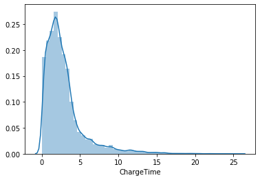

```python
# Exploration on charge time as one of the research task
sns.distplot(df["ChargeTime"])
```

```python
df["ChargeTime"].describe()
```

```
count    10000.00000
mean         2.87803
std          2.64428
min          0.02000
25%          1.25000
50%          2.24000
75%          3.50000
max         25.67000
Name: ChargeTime, dtype: float64
```

##### The distribution of Charge time is right skewed with a minimum charge time about 1 minute, and the maximum is around 25 hours and 40 minutes. We can initially identify the average charging time is around 2.87 hours (172 minutes).

#### Best Fitted Distribution (Optional)

##### Following function is to assist in idnetify the distribution of charge time which is identified as one of the most important features in predicting energy consumption.

```python
### Explore the distribution of Charge Time attribute
# f = Fitter(df["ChargeTime"])
# f.fit()
# f.summary()
```

```python
### Best fitted distributions
# f.get_best(method='sumsquare_error')
```

```python
### Plot 2 of the best fitted distributions
# f.plot_pdf(names=None, Nbest=3)
```

```python
### Mielke Distribution
# from scipy.stats import mielke
# k = 1.3273811958342832
# s = 2.687397473195703
# plt.hist(df["ChargeTime"], bins=100, density=True, alpha=0.5)
# x = np.linspace(df["ChargeTime"].min(), df["ChargeTime"].max(), 100)
# y = mielke.pdf(x, k = 1.3273811958342832, s = 2.687397473195703, loc = 0.01948294366089456, scale = 3.2952734938553743)
# plt.plot(x, y)
# plt.title("Mielke fit on ChargeTime data")
# plt.xlabel("ChargeTime")
```

```python
# import statsmodels.distributions
# ecdf=statsmodels.distributions.ECDF(df["ChargeTime"])
# plt.plot(x,ecdf(x),label="ChargeTimeCDF")
# plt.plot(x,mielke.cdf(x, k, s), label="Mielke")
# plt.title("Charge time CDF")
# plt.xlabel("ChargeTime")
# plt.legend()
```

#### Fit Weibull Distribution

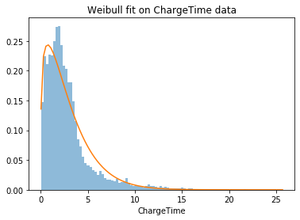

```python
# Weibull Distribution
from scipy.stats import weibull_min
plt.hist(df["ChargeTime"], bins=100, density=True, alpha=0.5)
shape, loc, scale = weibull_min.fit(df["ChargeTime"], floc=0)
x = np.linspace(df["ChargeTime"].min(), df["ChargeTime"].max(), 100)
plt.plot(x, weibull_min(shape, loc, scale).pdf(x))
plt.title("Weibull fit on ChargeTime data")
plt.xlabel("ChargeTime")
```

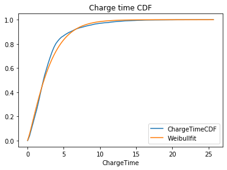

```python
# CDF for Weibull Distribution
import statsmodels.distributions
ecdf=statsmodels.distributions.ECDF(df["ChargeTime"])
plt.plot(x,ecdf(x),label="ChargeTimeCDF")
plt.plot(x,weibull_min(shape,loc,scale).cdf(x), label="Weibullfit")
plt.title("Charge time CDF")
plt.xlabel("ChargeTime")
plt.legend()
```

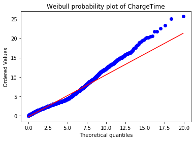

```python
# Probility plot of Weibull
from scipy.stats import probplot, weibull_min
probplot(df["ChargeTime"], dist=weibull_min(shape,loc,scale), plot=plt.figure().add_subplot(111))
plt.title("Weibull probability plot of ChargeTime")
```

```python
# Percent-Point Function
import scipy.stats
scipy.stats.weibull_min(shape, loc, scale).ppf(0.8)
```

```
4.564751407814518
```

##### Our dataset is well fitted in Weibull Distribution, and above percent-point function would give the discrete outcome that is less than or equal to a probability. i.e. In above cell, the result illustrates 80% of charging time is no longer than 4.56 hours.

#### Fit Lognormal Distribution

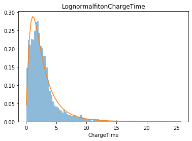

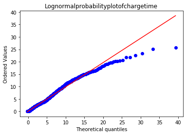

```python
# Lognormal Distribution
shape,loc,scale=scipy.stats.lognorm.fit(df["ChargeTime"])
fitted=scipy.stats.lognorm(shape,loc,scale)
plt.hist(df["ChargeTime"],bins=100,density=True,alpha=0.5)
x=np.linspace(df["ChargeTime"].min(),df["ChargeTime"].max(),100)
plt.plot(x,fitted.pdf(x))
plt.title("LognormalfitonChargeTime")
plt.xlabel("ChargeTime")
scipy.stats.probplot(df["ChargeTime"],dist=fitted, plot=plt.figure().add_subplot(111))
plt.title("Lognormalprobabilityplotofchargetime")
```

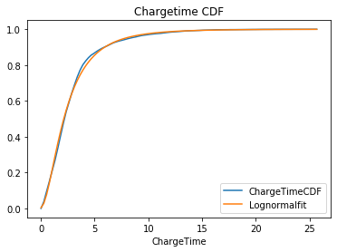

```python
# CDF for Lognormal Distribution
ecdf=statsmodels.distributions.ECDF(df["ChargeTime"])
plt.plot(x,ecdf(x),label="ChargeTimeCDF")
plt.plot(x,scipy.stats.lognorm(shape,loc,scale).cdf(x), label="Lognormalfit")
plt.title("Chargetime CDF")
plt.xlabel("ChargeTime")
plt.legend()
```

```python
# Percent-Point Function
scipy.stats.lognorm(shape,loc,scale).ppf(0.8)
```

```
4.223981024176113
```

##### Similar to Weibull Distribution, Lognormal Distribution also provides a good fit result which suggests 80% charging period is equal or less than 4.22 hours.

### Day of the Week

```python
# Charging event count
df["Day of the Week"].value_counts()
```

```
Saturday     1662
Friday       1530
Tuesday      1473
Wednesday    1446
Thursday     1441
Monday       1363
Sunday       1085
Name: Day of the Week, dtype: int64
```

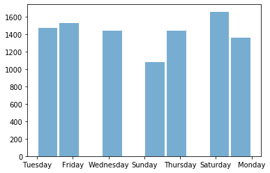

```python
# Plot Historgram of Day of the Week
plt.hist(df["Day of the Week"], alpha=0.6, rwidth=0.9)
```

##### Among all the seven days in a week, most charging events occurred on Saturday, while the least on Sunday. Frequencies for weekdays are quite similar.

### Day/Night

```python
# Day/Night charging event count
df["Day/Night"].value_counts()
```

```
Day      8017
Night    1983
Name: Day/Night, dtype: int64
```

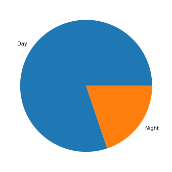

```python
# Plot Pie Chart of Day/Night
fig = plt.figure(figsize =(6, 6))
plt.pie(df["Day/Night"].value_counts(), labels = df["Day/Night"].value_counts().index)

# show plot
plt.show()
```

##### Most of the charging transactions are in the daytime, while around 20% occured at night.

### Peak/Off Peak

```python
# Peak/Off peak charging event count
df["Peak"].value_counts()
```

```
MID PEAK    4035
ON PEAK     4004
OFF PEAK    1961
Name: Peak, dtype: int64
```

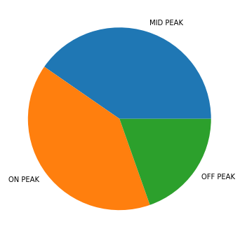

```python
# Plot Pie Chart of Peak/Off Peak
fig = plt.figure(figsize =(6, 6))
plt.pie(df["Peak"].value_counts(), labels = df["Peak"].value_counts().index)

# show plot
plt.show()
```

##### Most transactions occured at Peak and Mid Peak hours, and around 20% were at Off Peak hours.

### Season

```python
# Seasonal charging event count
df["Season"].value_counts()
```

```
Winter    5425
Summer    4575
Name: Season, dtype: int64
```

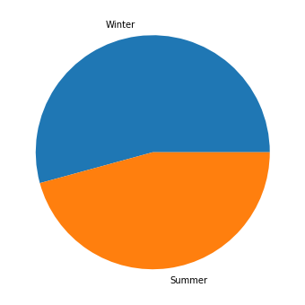

```python
# Plot Pie chart of Season
fig = plt.figure(figsize =(6, 6))
plt.pie(df["Season"].value_counts(), labels = df["Season"].value_counts().index)

# show plot
plt.show()
```

##### More charging events occured in Winter than in Summer.

### Total Energy

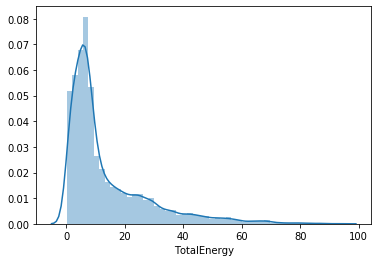

```python
# Histogram of Total Energy consumed
sns.distplot(df["TotalEnergy"])
```

```python
df["TotalEnergy"].describe()
```

```
count    10000.000000
mean        13.635216
std         14.282036
min          0.100000
25%          4.530000
50%          7.830000
75%         18.262500
max         93.929000
Name: TotalEnergy, dtype: float64
```

#### Best Fitted Distribution (Optional)

```python
### Best fitted distribution - OPtional
# f_totalenergy = Fitter(df["TotalEnergy"])
# f_totalenergy.fit()
# f_totalenergy.summary()
```

```python
# f_totalenergy.get_best(method='sumsquare_error')
```

```python
# f_totalenergy.plot_pdf(names=None, Nbest=2, lw=2)
```

#### Fit Lognormal Distribution

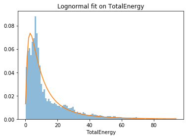

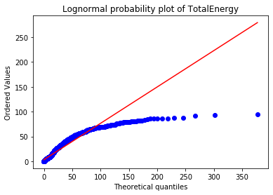

```python
# Lognormal Distribution
shape,loc,scale=scipy.stats.lognorm.fit(df["TotalEnergy"])
fitted=scipy.stats.lognorm(shape,loc,scale)
plt.hist(df["TotalEnergy"],bins=100,density=True,alpha=0.5)
x=np.linspace(df["TotalEnergy"].min(),df["TotalEnergy"].max(),100)
plt.plot(x,fitted.pdf(x))
plt.title("Lognormal fit on TotalEnergy")
plt.xlabel("TotalEnergy")
scipy.stats.probplot(df["TotalEnergy"],dist=fitted, plot=plt.figure().add_subplot(111))
plt.title("Lognormal probability plot of TotalEnergy")
```

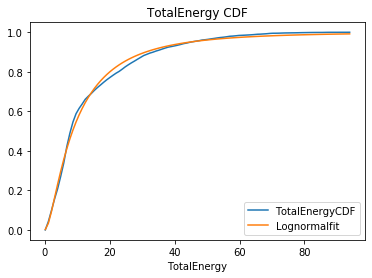

```python
ecdf=statsmodels.distributions.ECDF(df["TotalEnergy"])
plt.plot(x,ecdf(x),label="TotalEnergyCDF")
plt.plot(x,scipy.stats.lognorm(shape,loc,scale).cdf(x), label="Lognormalfit")
plt.title("TotalEnergy CDF")
plt.xlabel("TotalEnergy")
plt.legend()
```

### Connected Time

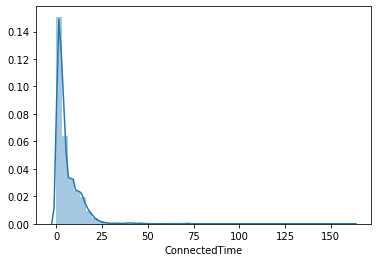

```python
# Histogram of Connected Time
sns.distplot(df["ConnectedTime"])
```

```python
df["ConnectedTime"].describe()
```

```
count    10000.000000
mean         5.822735
std          7.096361
min          0.020000
25%          1.510000
50%          3.380000
75%          8.410000
max        161.170000
Name: ConnectedTime, dtype: float64
```

##### Connected time is similar to charge time, while charge time would be a more precise attribute in estimating charging event time period.

### Transaction Start Time

```python
# Transaction Start Time
df['TransactionStartTime'] = pd.to_datetime(df['TransactionStartTime']).dt.time
```

```python
def chartsns(occurance_list):
    hour_list = [t.hour for t in occurance_list]
    numbers=[x for x in range(0,24)]
    labels=map(lambda x: str(x), numbers)
    plt.xticks(numbers, labels)
    plt.xlim(0,24)
    sns.distplot(hour_list)
    plt.show()

# Ref: https://stackoverflow.com/questions/8369584/plot-histogram-of-datetime-time-python-matplotlib
```

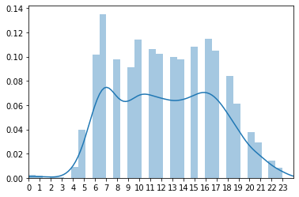

```python
chartsns(df["TransactionStartTime"])
```

##### We can identify that most of the charging behavior started at 4am, peaked at 7am and kept steady until about 5pm, then started to decline. It is obviously that most charging events occured between 7am and 5pm.

### Relationship Exploration Between All Attributes

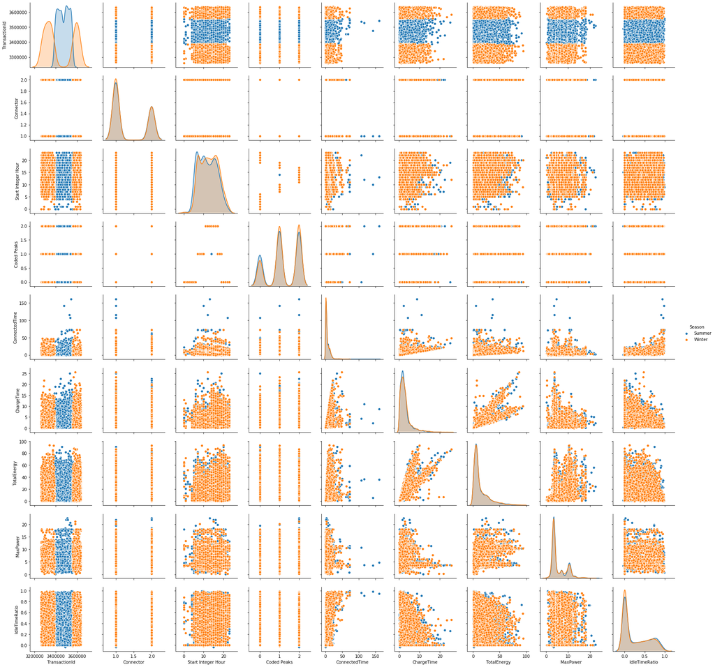

```python
sns.pairplot(df, hue="Season")
```

#### Relationship between Total Energy and Day of a Week / Hour of a Day (Start Integer Hour)

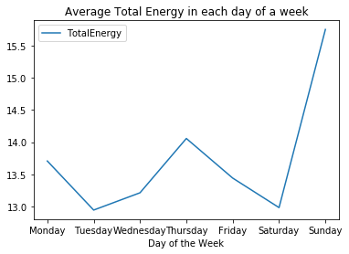

```python
# Investigate the total energy pattern in each day of a week
grouped_df_day = df["TotalEnergy"].groupby(df["Day of the Week"]).mean()
te_day = pd.DataFrame({"Day of the Week": grouped_df_day.index, "TotalEnergy":grouped_df_day.values})
day_order = ["Monday", "Tuesday", "Wednesday", "Thursday", "Friday", "Saturday", "Sunday"]
ax = te_day.set_index("Day of the Week").loc[day_order].plot(kind="line")
ax.set_title("Average Total Energy in each day of a week")
```

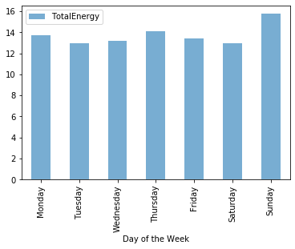

```python
ax1 = te_day.set_index("Day of the Week").loc[day_order].plot(kind="bar", alpha = 0.6)
```

##### From above line/bar charts, we could see Sunday consumed most energy even though there were least transactions occured from our previous analysis. This implies that EV drivers would have spent more time on public charging stations on Sanday than any other days in a week.

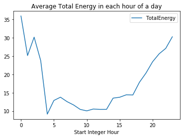

```python
# Investigate the total energy pattern in each hour of a day
grouped_df_hour = df["TotalEnergy"].groupby(df["Start Integer Hour"]).mean()
te_hour = pd.DataFrame({"Start Integer Hour": grouped_df_hour.index, "TotalEnergy":grouped_df_hour.values})
ax_hour = te_hour.set_index("Start Integer Hour").plot(kind="line")
ax_hour.set_title("Average Total Energy in each hour of a day")
```

##### The most average energy was consumed from night (after around 8pm) to next day morning (before around 3am). This may imply that many EV users would leave their vehicles at EVCS for the whole night or longer period than daytime.

#### Relationship between Charge Time and Total Energy¶

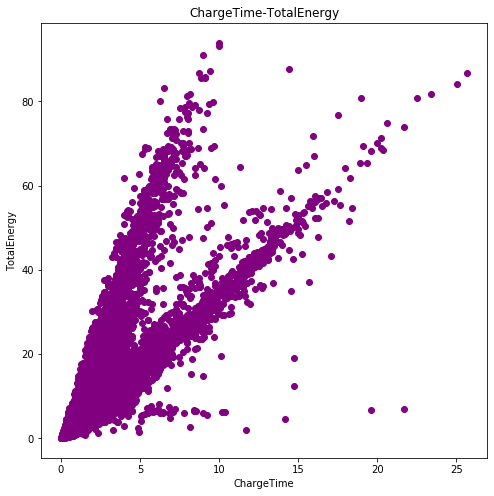

```python
# Create figure and plot space
fig, ax = plt.subplots(figsize=(8, 8))

# Add x-axis and y-axis
ax.scatter(df['ChargeTime'].values,
           df['TotalEnergy'],
           color='purple')

# Set title and labels for axes
ax.set(xlabel="ChargeTime",
       ylabel="TotalEnergy",
       title="ChargeTime-TotalEnergy")

plt.show()
```

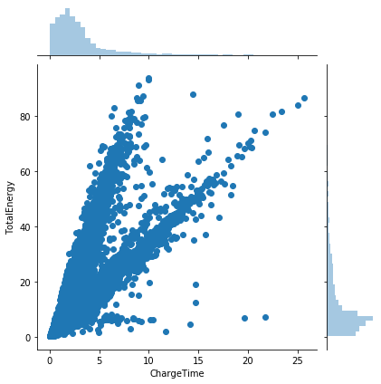

```python
sns.jointplot(x='ChargeTime', y='TotalEnergy', data=df)
```

##### It is obvious that relationships between Charge Time and Total Energy are linears; two separate trends in the above graphs would indicate two different charging types.

## Feature Selection

### Correlation Coefficient

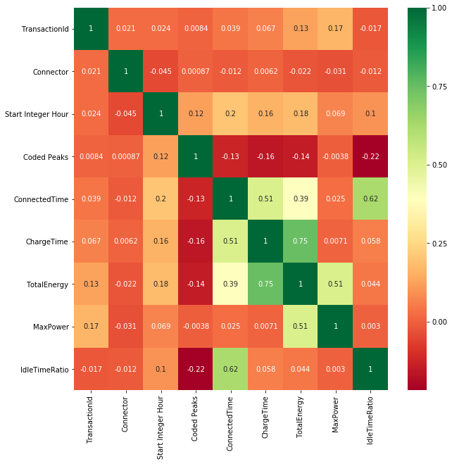

```python
# Check the Pearson correlation between different features
corrmat = df.corr()
top_corr_features = corrmat.index
plt.figure(figsize = (10, 10))
hm = sns.heatmap(df[top_corr_features].corr(), annot=True, cmap="RdYlGn")
```

##### Above Correlation Coefficients illustrate a strong linear relationship between Charge Time and Total Energy. Relationship between Total Energy and Max Power is moderate, while other features would have weak linear relationship with Total Energy.

### Feature Importance

```python
X_ = df.drop(["TotalEnergy","TransactionStartTime","TransactionStopTime"],1)
y_ = df["TotalEnergy"]
```

```python
# Label encoding
dn = {'Day':1, 'Night':0}
X_['Day/Night'] = X_['Day/Night'].map(dn)

peak = {'ON PEAK':2, 'MID PEAK':1, 'OFF PEAK':0}
X_['Peak'] = X_['Peak'].map(peak)

season = {'Spring':1, 'Summer':2, 'Autumn':3, 'Winter':4}
X_['Season'] = X_['Season'].map(season)

dow = {'Monday':1, 'Tuesday':2, 'Wednesday':3, 'Thursday':4, 'Friday':5, 'Saturday':6, 'Sunday':7}
X_['Day of the Week'] = X_['Day of the Week'].map(dow)
```

```python
X_["Date"] = pd.to_datetime(X_["UTCTransactionStart"]).dt.date
X_["Time"] = pd.to_datetime(X_["UTCTransactionStart"]).dt.time
```

```python
X_ = X_.drop(["UTCTransactionStart","UTCTransactionStop"],1)
X_features = X_.drop(["Date", "Time"],1)
```

```python
X_features.head()
```

|  | TransactionId | Connector | Day/Night | Start Integer Hour | Coded Peaks | Season | Peak | Day of the Week | ConnectedTime | ChargeTime | MaxPower | IdleTimeRatio |
| --- | --- | --- | --- | --- | --- | --- | --- | --- | --- | --- | --- | --- |
| 0 | 3491779 | 1 | 1 | 14 | 1.0 | 2 | 1 | 2 | 3.11 | 3.10 | 3.342 | 0.003215 |
| 1 | 3326963 | 2 | 1 | 10 | 1.0 | 4 | 2 | 5 | 3.00 | 3.00 | 3.440 | 0.000000 |
| 2 | 3469263 | 1 | 1 | 12 | 2.0 | 2 | 1 | 3 | 0.46 | 0.46 | 3.160 | 0.000000 |
| 3 | 3429356 | 1 | 1 | 10 | 1.0 | 2 | 2 | 7 | 3.65 | 3.65 | 10.813 | 0.000000 |
| 4 | 3332751 | 1 | 0 | 21 | 0.0 | 4 | 0 | 4 | 10.03 | 7.15 | 3.884 | 0.287139 |

```python
X_ = X_.sort_values(by = ["Date"])
X_.head()
```

|  | TransactionId | Connector | Day/Night | Start Integer Hour | Coded Peaks | Season | Peak | Day of the Week | ConnectedTime | ChargeTime | MaxPower | IdleTimeRatio | Date | Time |
| --- | --- | --- | --- | --- | --- | --- | --- | --- | --- | --- | --- | --- | --- | --- |
| 7021 | 3262697 | 1 | 1 | 17 | 1.0 | 4 | 2 | 2 | 2.07 | 2.07 | 3.240 | 0.000000 | 2019-01-01 | 17:54:00 |
| 2056 | 3262660 | 2 | 1 | 17 | 1.0 | 4 | 2 | 2 | 18.31 | 2.31 | 3.560 | 0.873839 | 2019-01-01 | 17:20:00 |
| 461 | 3262735 | 1 | 1 | 14 | 2.0 | 4 | 1 | 2 | 0.60 | 0.60 | 10.154 | 0.000000 | 2019-01-01 | 14:03:00 |
| 1718 | 3262516 | 1 | 1 | 15 | 2.0 | 4 | 1 | 2 | 1.67 | 1.67 | 3.552 | 0.000000 | 2019-01-01 | 15:47:00 |
| 2218 | 3262845 | 1 | 0 | 21 | 0.0 | 4 | 0 | 2 | 0.29 | 0.29 | 3.498 | 0.000000 | 2019-01-01 | 21:32:00 |

```python
from sklearn.ensemble import ExtraTreesRegressor
model = ExtraTreesRegressor()
model.fit(X_features, y_)
```

```
ExtraTreesRegressor()
```

```python
print(model.feature_importances_)
```

```
[0.00659322 0.00357416 0.00216164 0.01031508 0.00445175 0.00354891
 0.00355685 0.00475877 0.0302763  0.61235074 0.30155445 0.01685813]
```

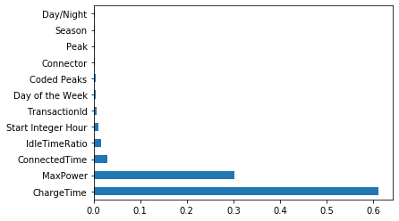

```python
feature_importances = pd.Series(model.feature_importances_, index = X_features.columns)
feature_importances.nlargest(12).plot(kind = "barh")
plt.show()
```

##### Top Five important features in prediction Total Energy: Charge Time, Max Power, Connected Time, Idle Time Ratio, and Start Integer Hour.

### Prediction Model

```python
from sklearn.model_selection import train_test_split
X_train, X_test, y_train, y_test = train_test_split(X_features, y_, test_size = 0.3)
```

```python
from sklearn.ensemble import RandomForestRegressor
rf_random = RandomForestRegressor()
```

```python
# Hpyer-parameters
n_estimators = [int(x) for x in np.linspace(start = 100, stop = 1000, num = 10)]
max_features = ["auto", "sqrt"]
max_depth = [int(x) for x in np.linspace(5, 30, num = 6)]
min_samples_split = [2, 5, 10, 15, 100]
min_samples_leaf = [1, 2, 5, 10]
```

```python
from sklearn.model_selection import RandomizedSearchCV
random_grid = {"n_estimators": n_estimators,
              "max_features": max_features,
              "max_depth": max_depth,
              "min_samples_split": min_samples_split,
              "min_samples_leaf": min_samples_leaf}
```

```python
rf = RandomForestRegressor()
```

```python
rf_random = RandomizedSearchCV(estimator = rf, param_distributions = random_grid,
                              scoring = "neg_mean_squared_error", n_iter = 10, cv = 5,
                              verbose = 2, random_state = 42, n_jobs = 1)
```

```python
rf_random.fit(X_train, y_train)
```

```
Fitting 5 folds for each of 10 candidates, totalling 50 fits
[CV] END max_depth=15, max_features=auto, min_samples_leaf=2, min_samples_split=5, n_estimators=100; total time=   2.7s
[CV] END max_depth=15, max_features=auto, min_samples_leaf=2, min_samples_split=5, n_estimators=100; total time=   3.9s
[CV] END max_depth=15, max_features=auto, min_samples_leaf=2, min_samples_split=5, n_estimators=100; total time=   2.9s
[CV] END max_depth=15, max_features=auto, min_samples_leaf=2, min_samples_split=5, n_estimators=100; total time=   2.2s
[CV] END max_depth=15, max_features=auto, min_samples_leaf=2, min_samples_split=5, n_estimators=100; total time=   2.1s
[CV] END max_depth=20, max_features=auto, min_samples_leaf=2, min_samples_split=100, n_estimators=500; total time=   7.4s
[CV] END max_depth=20, max_features=auto, min_samples_leaf=2, min_samples_split=100, n_estimators=500; total time=   7.8s
[CV] END max_depth=20, max_features=auto, min_samples_leaf=2, min_samples_split=100, n_estimators=500; total time=   9.3s
[CV] END max_depth=20, max_features=auto, min_samples_leaf=2, min_samples_split=100, n_estimators=500; total time=  15.1s
[CV] END max_depth=20, max_features=auto, min_samples_leaf=2, min_samples_split=100, n_estimators=500; total time=   8.3s
[CV] END max_depth=15, max_features=sqrt, min_samples_leaf=5, min_samples_split=15, n_estimators=100; total time=   0.9s
[CV] END max_depth=15, max_features=sqrt, min_samples_leaf=5, min_samples_split=15, n_estimators=100; total time=   0.7s
[CV] END max_depth=15, max_features=sqrt, min_samples_leaf=5, min_samples_split=15, n_estimators=100; total time=   0.6s
[CV] END max_depth=15, max_features=sqrt, min_samples_leaf=5, min_samples_split=15, n_estimators=100; total time=   0.6s
[CV] END max_depth=15, max_features=sqrt, min_samples_leaf=5, min_samples_split=15, n_estimators=100; total time=   0.7s
[CV] END max_depth=15, max_features=sqrt, min_samples_leaf=2, min_samples_split=100, n_estimators=600; total time=   3.3s
[CV] END max_depth=15, max_features=sqrt, min_samples_leaf=2, min_samples_split=100, n_estimators=600; total time=   3.2s
[CV] END max_depth=15, max_features=sqrt, min_samples_leaf=2, min_samples_split=100, n_estimators=600; total time=   2.5s
[CV] END max_depth=15, max_features=sqrt, min_samples_leaf=2, min_samples_split=100, n_estimators=600; total time=   2.6s
[CV] END max_depth=15, max_features=sqrt, min_samples_leaf=2, min_samples_split=100, n_estimators=600; total time=   3.1s
[CV] END max_depth=25, max_features=auto, min_samples_leaf=1, min_samples_split=15, n_estimators=900; total time=  18.3s
[CV] END max_depth=25, max_features=auto, min_samples_leaf=1, min_samples_split=15, n_estimators=900; total time=  23.1s
[CV] END max_depth=25, max_features=auto, min_samples_leaf=1, min_samples_split=15, n_estimators=900; total time=  15.6s
[CV] END max_depth=25, max_features=auto, min_samples_leaf=1, min_samples_split=15, n_estimators=900; total time=  15.0s
[CV] END max_depth=25, max_features=auto, min_samples_leaf=1, min_samples_split=15, n_estimators=900; total time=  14.4s
[CV] END max_depth=30, max_features=auto, min_samples_leaf=10, min_samples_split=5, n_estimators=1000; total time=  13.7s
[CV] END max_depth=30, max_features=auto, min_samples_leaf=10, min_samples_split=5, n_estimators=1000; total time=  14.0s
[CV] END max_depth=30, max_features=auto, min_samples_leaf=10, min_samples_split=5, n_estimators=1000; total time=  13.7s
[CV] END max_depth=30, max_features=auto, min_samples_leaf=10, min_samples_split=5, n_estimators=1000; total time=  14.0s
[CV] END max_depth=30, max_features=auto, min_samples_leaf=10, min_samples_split=5, n_estimators=1000; total time=  13.8s
[CV] END max_depth=10, max_features=auto, min_samples_leaf=2, min_samples_split=5, n_estimators=700; total time=  10.3s
[CV] END max_depth=10, max_features=auto, min_samples_leaf=2, min_samples_split=5, n_estimators=700; total time=  10.4s
[CV] END max_depth=10, max_features=auto, min_samples_leaf=2, min_samples_split=5, n_estimators=700; total time=  11.2s
```

[output cut: 17 more lines]

```
RandomizedSearchCV(cv=5, estimator=RandomForestRegressor(), n_jobs=1,
                   param_distributions={'max_depth': [5, 10, 15, 20, 25, 30],
                                        'max_features': ['auto', 'sqrt'],
                                        'min_samples_leaf': [1, 2, 5, 10],
                                        'min_samples_split': [2, 5, 10, 15,
                                                              100],
                                        'n_estimators': [100, 200, 300, 400,
                                                         500, 600, 700, 800,
                                                         900, 1000]},
                   random_state=42, scoring='neg_mean_squared_error',
                   verbose=2)
```

```python
predictions = rf_random.predict(X_test)
```

```python
predictions = pd.DataFrame(predictions)
predictions.columns = ["Predictions"]
predictions
```

|  | Predictions |
| --- | --- |
| 0 | 18.297584 |
| 1 | 3.137959 |
| 2 | 5.505616 |
| 3 | 47.604908 |
| 4 | 8.426309 |
| ... | ... |
| 2995 | 10.715133 |
| 2996 | 3.596131 |
| 2997 | 6.973773 |
| 2998 | 4.424234 |
| 2999 | 4.811659 |

3000 rows × 1 columns

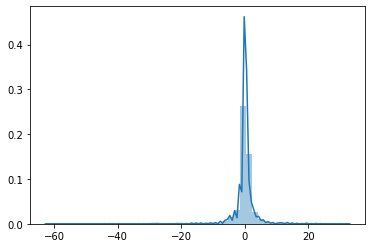

```python
y_true = y_test.reset_index()
sns.distplot(y_true["TotalEnergy"] - predictions["Predictions"])
```

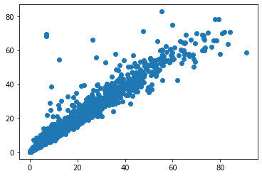

```python
plt.scatter(y_true["TotalEnergy"], predictions["Predictions"])
```

#### Model Performance

```python
# Evaluation Metrics
from sklearn.metrics import mean_squared_error
mse = mean_squared_error(y_true["TotalEnergy"], predictions["Predictions"])
rmse = mse**.5
print(mse)
print(rmse)
```

```
12.429850100287299
3.5255992540683487
```

```python
mape = np.mean(np.abs((y_true["TotalEnergy"] - predictions["Predictions"]) / np.abs(y_true["TotalEnergy"])))
print('Accuracy:', round(100*(1 - mape), 2), "%")
```

```
Accuracy: 87.33 %
```

##### We built a prediction model based on Random Forest algorithm to make predictions on Total Energy. Hyper-parameters are tuned by using Randomized Search function, and cross-validation applied for generalisation purpose. The model returns a Mean-square Error (MSE) of 12.43, a Root-mean-square Error (RMSE) of 3.53, and an accuracy of 87.33%.

##### Our prediction model result reveals that there's quite a strong relationship between the charge time period and the total energy consumption. In future work, we would like to investigate in-depth how the charge time / total energy would vary depending on different locations and regions.